# Comparison of size and location data between estrogen-receptor positive (er_pos) and triple-negative (trip_neg) breast cancer tumors

Jazmine A. Snow

2020-12-14

This code is in connection with the TFCB Capstone project (homework 8). I am using a the raw dataset from https://datadryad.org/stash/dataset/doi:10.5061/dryad.32765 to answer two specific questions that are described below.

## Questions for R analysis

### Question 2

Did the average size of the tumor change between the triple-negative (trip_neg) tumors and the estrogen-receptor positive (er_pos) tumors?

### Question 3

Were there locational differences between triple-negative (trip_neg) tumors and the estrogen-receptor positive (er_pos) tumors?

## Setup for projects

### Install/Load packages

Below allows you to load all of the packages necessary for this project. If you do not have these packages installed, please use the install.packages() function beforehand.

```r
library(tidyverse)
library(dplyr)

library(dbplyr)
```

```r
library(ggplot2)
```

### Load file for project

Load the file that contains the information given for this project. In this case, it is a csv file.

```r
# Created a new variable called filename that will have the file that is being used.
filename <- "../edited-data/tumor-location_edited-data_csv.csv"

# Created a new variable called "raw_data" that reads the csv file I created of the raw-data.
raw_data <- read.csv(filename, as.is = TRUE) %>%

# Had to change the id name because it adds a weird character to it, I believe that this is because it was originally an excel file.
  rename(id = `ï..id`)

# Printing out just the first few rows just for reference.
head(raw_data)
```

```
##   id size_cm subtype quadrants mr_location_ml mr_location_ap y_distance x_norm
## 1  1     1.5       1         2              2              2        1.7    0.0
## 2  2     3.0       1         2              2              3        0.1    0.0
## 3  3     1.6       1         1              2              2        3.9    0.0
## 4  4     1.8       1         5              2              2        3.5    0.0
## 5  5     3.0       1         1              2              3        0.3   -0.1
## 6  6     3.5       3         1              2              2        0.9    0.0
##   y_norm z_norm grade x_distance z_distance palpability histology
## 1    0.2    0.2     3       -0.3        2.7           0         2
## 2    0.0    0.5     3       -0.4        6.7           1         2
## 3    0.4    0.1     3        0.2        1.2           1         2
## 4    0.4    0.0     3       -0.3       -0.6           0         2
## 5    0.1    0.0     4       -0.5        0.5           1         2
## 6    0.1    0.1     3        0.0        1.3           1         3
```

For this file, I had already tidied the column names and the data beforehand to make it easier to use for analysis in R. For the column names, I removed any spaces and made sure it wasn’t case dependent. For the data, I added “NA” to any of the data that did not have size information. However, the rest of the information was present for all the samples.

### Remove any samples that do not have tumor size recorded

Not all of the samples had its tumor size recorded. Therefore, I decided to remove any data that does not have a numerical symbol in the size_cm column.

```r
# I created a new variable called "num_data" that stands for numerical data and added the raw_data dataframe to this variable.
num_data <- raw_data %>%

# Filtered out any samples that did not have size information.
  filter(!is.na(size_cm))

# Printing out just the first few rows just for reference.
head(num_data)
```

```
##   id size_cm subtype quadrants mr_location_ml mr_location_ap y_distance x_norm
## 1  1     1.5       1         2              2              2        1.7    0.0
## 2  2     3.0       1         2              2              3        0.1    0.0
## 3  3     1.6       1         1              2              2        3.9    0.0
## 4  4     1.8       1         5              2              2        3.5    0.0
## 5  5     3.0       1         1              2              3        0.3   -0.1
## 6  6     3.5       3         1              2              2        0.9    0.0
##   y_norm z_norm grade x_distance z_distance palpability histology
## 1    0.2    0.2     3       -0.3        2.7           0         2
## 2    0.0    0.5     3       -0.4        6.7           1         2
## 3    0.4    0.1     3        0.2        1.2           1         2
## 4    0.4    0.0     3       -0.3       -0.6           0         2
## 5    0.1    0.0     4       -0.5        0.5           1         2
## 6    0.1    0.1     3        0.0        1.3           1         3
```

Above you can see that the id numbers 200-212 and 1025-1102 have been removed from this dataframe.

### Separate the dataframe into er_pos and trip_n samples

Currently, the two different sample subtypes are mixed together in this dataframe “num_data”. To compare between the two subtypes, I decided to create separate dataframes for the er_pos and trip_neg data.

```r
# Created a separate variable for er_pos tumors (denoted by "1" in subtype column).
er_pos <- num_data %>%

# Filtered the data so that only the rows with er_pos tumors are in this dataframe.
  filter(subtype == 1)

# Changed the subtype column to now have er_pos instead of "1".
er_pos$subtype <- "er_pos"

# Printing out just the first few rows just for reference.
head(er_pos)
```

```
##   id size_cm subtype quadrants mr_location_ml mr_location_ap y_distance x_norm
## 1  1     1.5  er_pos         2              2              2        1.7    0.0
## 2  2     3.0  er_pos         2              2              3        0.1    0.0
## 3  3     1.6  er_pos         1              2              2        3.9    0.0
## 4  4     1.8  er_pos         5              2              2        3.5    0.0
## 5  5     3.0  er_pos         1              2              3        0.3   -0.1
## 6  9     2.3  er_pos         1              2              2        5.0    0.0
##   y_norm z_norm grade x_distance z_distance palpability histology
## 1    0.2    0.2     3       -0.3        2.7           0         2
## 2    0.0    0.5     3       -0.4        6.7           1         2
## 3    0.4    0.1     3        0.2        1.2           1         2
## 4    0.4    0.0     3       -0.3       -0.6           0         2
## 5    0.1    0.0     4       -0.5        0.5           1         2
## 6    0.5    0.2     3        0.0        3.4           1         2
```

```r
# Created a separate variable for trip_neg tumors (denoted by a "3" in subtype column).
trip_neg <- num_data %>%

# Filtered the data so that only the rows with trip_neg tumors are in this dataframe.
  filter(subtype == 3)

# Changed the subtype column to now have trip_neg instead of "3".
trip_neg$subtype <- "trip_neg"

# Printing out just the first few rows just for reference.
head(trip_neg)
```

```
##   id size_cm  subtype quadrants mr_location_ml mr_location_ap y_distance x_norm
## 1  6     3.5 trip_neg         1              2              2        0.9    0.0
## 2  7     2.2 trip_neg         2              2              3        1.0   -0.1
## 3  8     2.6 trip_neg         2              2              3        1.1    0.0
## 4 12     5.0 trip_neg         5              2              1        2.0   -0.1
## 5 13     2.6 trip_neg         1              2              2        2.7    0.0
## 6 17     4.5 trip_neg         1              2              2        3.4    0.0
##   y_norm z_norm grade x_distance z_distance palpability histology
## 1    0.1    0.1     3        0.0        1.3           1         3
## 2    0.1    0.3     3       -1.0        3.7           1         3
## 3    0.1    0.2     3       -0.4        3.0           1         3
## 4    0.3    0.1     4       -0.6        1.4           0         3
## 5    0.3    0.2     3        0.0        2.8           1         3
## 6    0.3    0.1     1        0.2        1.2           1         3
```

```r
# Calculated the number of samples in each subtype by counting the number of rows in each dataframe.
# Created a new dataframe with the count of er_pos and trip_neg tumors to use for later analysis.
er_pos_tumor_number <- nrow(er_pos)
trip_neg_tumor_number <- nrow(trip_neg)
```

For my data, there are 782 samples that are ER-positive and 229 samples that are triple-negative tumors.

### Combined the two dataframes back into one dataframe

Now that I was able to change the labels for the tumor subtype, we need to combine the two dataframes back together to compare the data.

```r
# Created a new variable called assigned_data that now has the subtype names in the column labeled subtype.
# Joined the two dataframes together with code generated with the help of https://www.statmethods.net/management/merging.html . Since they don't have any matching columns, I had to use rbind instead of join.
assigned_data <- rbind(er_pos, trip_neg) %>%

# Used the arrange() function to have the samples ordered by increasing id number. Without this, all of the er_pos data would be above the trip_neg data.
  arrange(id)

head(assigned_data)
```

```
##   id size_cm  subtype quadrants mr_location_ml mr_location_ap y_distance x_norm
## 1  1     1.5   er_pos         2              2              2        1.7    0.0
## 2  2     3.0   er_pos         2              2              3        0.1    0.0
## 3  3     1.6   er_pos         1              2              2        3.9    0.0
## 4  4     1.8   er_pos         5              2              2        3.5    0.0
## 5  5     3.0   er_pos         1              2              3        0.3   -0.1
## 6  6     3.5 trip_neg         1              2              2        0.9    0.0
##   y_norm z_norm grade x_distance z_distance palpability histology
## 1    0.2    0.2     3       -0.3        2.7           0         2
## 2    0.0    0.5     3       -0.4        6.7           1         2
## 3    0.4    0.1     3        0.2        1.2           1         2
## 4    0.4    0.0     3       -0.3       -0.6           0         2
## 5    0.1    0.0     4       -0.5        0.5           1         2
## 6    0.1    0.1     3        0.0        1.3           1         3
```

Now that the data is arranged the way that is most conducive for me, I can continue to the analysis portions.

## Question 2: Did the average size of the tumor change between the trip_neg tumors and the er_pos tumors?

### Calculate the average tumor size of each tumor subtype

To compare tumor size, I will calculate the average tumor size for each subtype as well as its standard deviation from the mean.

```r
# Created a new variable called "size_stats" and added the assigned_data to it.
size_stats <- assigned_data %>%
# To observe difference in subtype, I grouped the data by its subtype.
  group_by(subtype) %>%
# I used the summarize function to create a new table that has the mean tumor size and the standard deviation of each tumor size subtype.
  summarize(mean_tumor_size = mean(size_cm), st.dev_tumor_size = sd(size_cm)) %>%
  print()
```

```
## # A tibble: 2 x 3
##   subtype  mean_tumor_size st.dev_tumor_size
##   <chr>              <dbl>             <dbl>
## 1 er_pos              2.41              1.30
## 2 trip_neg            2.65              1.17
```

The average tumor size for ER-positive samples is 2.41 with a standard deviation of +- 1.30. The average tumor size for triple-negative samples is 2.65 with a standard deviation of +- 1.17. Just by looking at the data, it does not appear that there is a signficant change in tumor size between the two subtypes.

### Graph tumor size data

To visualize this data, I decided to use a bar graph. I picked a bar graph because I think that it best represents the data derived from my analysis. Since I am only comparing one variable (mean tumor size) between the two subtypes, I think that a bar graph will portray my data accurately and understandably.

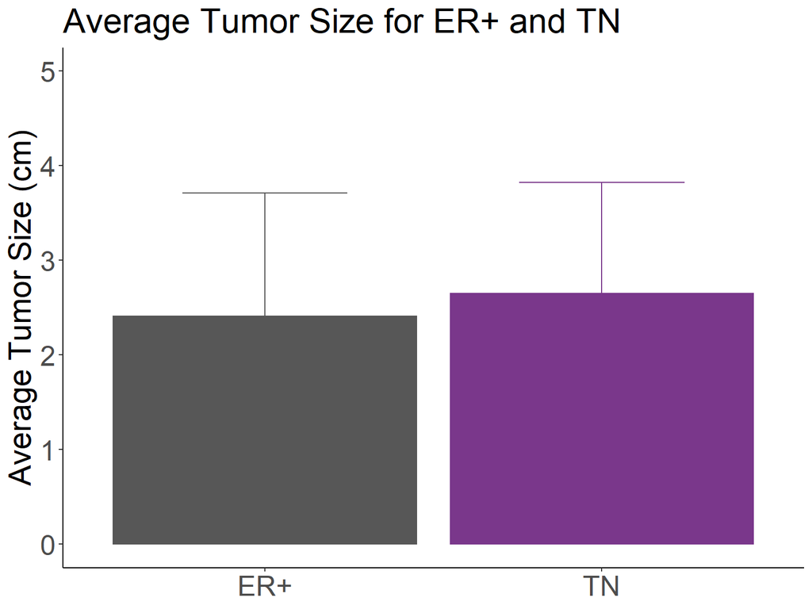

```r
size_stats %>%
# Made a graph using ggplot with subtype on the x axis, mean tumor size on the y avis, where the two different subtypes are also separated by color and fill of the bars.
  ggplot(aes(subtype, mean_tumor_size, color = subtype, fill = subtype)) +
# Used geom_col to make the bar plot since we are comparing two different variables.
  geom_col() +
# Used the classic theme to have a plain white background for the graph.
  theme_classic() +
# Added error bars that have the standard deviation data represented. I also changed the width of the error bars to make them easier to see.
  geom_errorbar(aes(ymin = mean_tumor_size - st.dev_tumor_size , ymax = mean_tumor_size + st.dev_tumor_size, width = 0.49)) +
# Added a title to this graph where ER+ stands for er_pos and TN stands for trip_neg tumors.
  ggtitle("Average Tumor Size for ER+ and TN") +
# Removed the x axis label since it was not necessary for this graph and added a label for the y axis.
  labs(x = NULL, y = "Average Tumor Size (cm)") +
# Increased the size of the text to have it better conform to proportional ink standards. Also hid the legend by having its position be "none" since it is already given on the x axis.
  theme(axis.text = element_text(size = 20), axis.title = element_text(size = 22), plot.title = element_text(size = 24), legend.position = "none") +
  # Changed the x axis labels using the help of http://www.sthda.com/english/wiki/ggplot2-axis-ticks-a-guide-to-customize-tick-marks-and-labels
  scale_x_discrete(labels = c("er_pos" = "ER+", "trip_neg" = "TN")) +
# Changed the colors for color and fill from the default to having the er_pos samples in grey and the trip_neg samples in purple. This was just a personal choice.
  scale_fill_manual(values = c("grey34", "mediumorchid4")) +
  scale_color_manual(values = c("grey34", "mediumorchid4")) +
# Increased the y axis scale from 4 to 5 because the data was looking a little cramped.
  ylim(0,5)
```

```r
# Save the figure using ggsave
  #ggsave("tfcb-capstone_question02_tumor-size-comparison_bar-graph-figure.jpg")
```

This bar graph visualizes the table shown above.

### Conclusions

There does not seem to be a difference in average tumor size between ER-positive and triple-negative breast cancers in this dataset. This is consistent with the findings that the authors made in the associated paper. It is interesting when taken into the context of question 1 where there looks to be an increase in pathology with triple-negative tumors when compared to ER-positive tumors. This shows that there is not always a correlation between tumor size and severity.

## Question 3: Were there locational differences between the trip_neg tumors and the er_pos tumors?

### Compare quadrant data between the two tumor subtypes

To answer this question, I decided to make a table calculating the number and percentage of the subtypes that are in each specific quadrant.

```r
# Created a list with the names of each quadrant in the order of what they correspond to numerically on the raw_data.
quadrant_names <- c("UO", "UI", "LO", "LI", "Peri")

# Calculated the number of ER positive tumors in each quadrant using summarize and table.
quadrant_data_er_pos <- er_pos %>%
  summarize(quadrants = quadrant_names, er_pos_count = table(er_pos$quadrants))

# Calculated the number of triple-negative tumors in each quadrant using summarize and table.
quadrant_data_trip_neg <- trip_neg %>%
  summarize(quadrants = quadrant_names, trip_neg_count = table(trip_neg$quadrants))

# Joined the two dataframes created above to form one table based on the quadrant locations.
quadrant_counts <- inner_join(quadrant_data_er_pos, quadrant_data_trip_neg, by = "quadrants")

# Added the percentages for each of the subtypes by mutating the table to form new columns for each one.
quadrant_data <- quadrant_counts %>%
  mutate(quadrant_counts, er_pos_percent = (( er_pos_count / er_pos_tumor_number) * 100), trip_neg_percent = ((trip_neg_count / trip_neg_tumor_number) * 100))

# Created a list with the names of each column to reorder the way they are presented to make it easier to compare the data.
quadrant_column_order <- c("quadrants", "er_pos_count", "er_pos_percent", "trip_neg_count", "trip_neg_percent")

# Rearranged the data so that the columns match the quadrant_column_order created above.
quadrant_data <- quadrant_data[, quadrant_column_order ] %>%
  print()
```

```
##   quadrants er_pos_count er_pos_percent trip_neg_count trip_neg_percent
## 1        UO          344      43.989770            113        49.344978
## 2        UI          207      26.470588             63        27.510917
## 3        LO          107      13.682864             23        10.043668
## 4        LI           56       7.161125             18         7.860262
## 5      Peri           68       8.695652             12         5.240175
```

```r
# Created a list with the names of each ml location in the order of what they correspond to numerically on the raw_data.
ml_location_names <- c("medial", "central" ,"lateral")

# Calculated the number of ER positive tumors in each ml location using summarize and table.
ml_data_er_pos <- er_pos %>%
  summarize(ml_location = ml_location_names, er_pos_count = table(er_pos$mr_location_ml))

# Calculated the number of triple-negative tumors in each ml location using summarize and table.
ml_data_trip_neg <- trip_neg %>%
  summarize(ml_location = ml_location_names, trip_neg_count = table(trip_neg$mr_location_ml))

# Joined the two dataframes created above to form one table based on the ml locations.
ml_location_counts <- inner_join(ml_data_er_pos, ml_data_trip_neg, by = "ml_location")

# Added the percentages for each of the subtypes by mutating the table to form new columns for each one.
ml_location_data <- ml_location_counts %>%
  mutate(ml_location_counts, er_pos_percent = (( er_pos_count / er_pos_tumor_number) * 100), trip_neg_percent = ((trip_neg_count / trip_neg_tumor_number) * 100))

# Created a list with the names of each column to reorder the way they are presented to make it easier to compare the data.
ml_location_column_order <- c("ml_location", "er_pos_count", "er_pos_percent", "trip_neg_count", "trip_neg_percent")

# Rearranged the data so that the columns match the ml_location_column_order created above.
ml_location_data <- ml_location_data[, ml_location_column_order ] %>%
  print()
```

```
##   ml_location er_pos_count er_pos_percent trip_neg_count trip_neg_percent
## 1      medial          172       21.99488             48         20.96070
## 2     central          284       36.31714             87         37.99127
## 3     lateral          326       41.68798             94         41.04803
```

### Compare the anteroposterior (ap) location data between the two tumor subtypes

To answer this question, I decided to make a table calculating the number and percentage of the subtypes that are in each specific anteroposterior location from the MRI data.

```r
# Created a list with the names of each ap location in the order of what they correspond to numerically on the raw_data.
ap_location_names <- c("anterior", "middle" ,"posterior")

# Calculated the number of ER positive tumors in each ap location using summarize and table.
ap_data_er_pos <- er_pos %>%
  summarize(ap_location = ap_location_names, er_pos_count = table(er_pos$mr_location_ap))

# Calculated the number of triple-negative tumors in each ap location using summarize and table.
ap_data_trip_neg <- trip_neg %>%
  summarize(ap_location = ap_location_names, trip_neg_count = table(trip_neg$mr_location_ap))

# Joined the two dataframes created above to form one table based on the ap locations.
ap_location_counts <- inner_join(ap_data_er_pos, ap_data_trip_neg, by = "ap_location")

# Added the percentages for each of the subtypes by mutating the table to form new columns for each one.
ap_location_data <- ap_location_counts %>%
  mutate(ap_location_counts, er_pos_percent = (( er_pos_count / er_pos_tumor_number) * 100), trip_neg_percent = ((trip_neg_count / trip_neg_tumor_number) * 100))

# Created a list with the names of each column to reorder the way they are presented to make it easier to compare the data.
ap_location_column_order <- c("ap_location", "er_pos_count", "er_pos_percent", "trip_neg_count", "trip_neg_percent")

# Rearranged the data so that the columns match the ap_location_column_order created above.
ap_location_data <- ap_location_data[, ap_location_column_order ] %>%
  print()
```

```
##   ap_location er_pos_count er_pos_percent trip_neg_count trip_neg_percent
## 1    anterior           73       9.335038             16          6.98690
## 2      middle          368      47.058824             83         36.24454
## 3   posterior          341      43.606138            130         56.76856
```

### Conclusions

Statistical analysis would need to be performed to really determine any differences between the estrogen-receptor positive and triple-negative breast cancer tumors. However, I can draw some general conclusions which I will highlight below:

#### Quadrant data analysis

From looking at the graph I generated for comparing the differences in quadrant location between er_pos and trip_neg tumors, there does not seem to be a difference. The percentages are all relatively similar between the two subtypes. There is a slight changes in the percentages but nothing drastic.

#### Mediolateral location data analysis

From looking at the graph I generated for comparing the differences in mediolateral location between er_pos and trip_neg tumors, there did not seem to be a difference either. The percentages were even more similar than the quadrant data. It does not look like there was a difference in mediolateral location between the two subtypes.

#### Anteroposterior location data analysis

From looking at the graph I generated for comparing the differences in anteroposterior location between er_pos and trip_neg tumors, there seems to be a possible preference for trip_neg tumors to locate in the posterior area. Whether this is significant or not cannot be determined by my table. Of all the data, this increase in posterior location of trip_neg tumors is the most apparent phenotype present.